# Exploratory Data Analysis (EDA) with Python

January 2019

Melvin Ott, PhD

Linear regression model building begins with a thorough look at the quality of the data and focuses on how to repair faulty data. Students are given direction with Python code on how to find and repair this faulty data. Some students follow this and provide very good repair while others overlook this very important step. To help these students that overlook the repair step, I have drafted this example which will show model performance improvement with increasing levels of data repair. The repair process fits within what is called Exploratory Data Analysis.

A question often asked is, "How do I do EDA?" The answer is not a simple one because data is often collected in a haphazard way or may be corrupted by unknown sources. Or, in some cases it may even be the wrong data.

Missing data, finding and fixing records that may be duplicates, out of range or outlier values, and issues that are application specific all present a challenge.

Keep in mind there are as many unknown data issues as there are ways to make mistakes. Not all are discoverable. But the best way to find them is to look at each dataset as a new challenge.

For example, health care claims data has issues that are application specific. There are code combinations that are denied for payment for many different reasons. There may be duplicate claims and claims that are for noncovered services, billed to wrong insurance and many more. When in doubt work with paid claims. Paid claims will remove most of these issues but some duplicate claims may still be paid.

So, the answer is dependent on the application and the best EDA will likely be performed by an individual that has knowledge of the industry and has the experience to deal with suspect data.

For this example a few of these issues are addressed in a fairly simple dataset. These are missing values, duplicate records, and out of range values. But the process described should be transferable to other datasets.

Finally, after the EDA, a scatter plot with color for a third variable suggests a more complex model. An engineer told me once that you cannot present data with more than two variables in two dimensions. He was wrong. You can do it with color and you can do it with size for the plot tick marks.

```
Section 1 Import and Explore
Section 2 Base Model and RMSE Score
Section 3 RMSE Score (after removing duplicate records)
Section 4 RMSE Score (after EDA fixing outliers and missing data)
Section 5 More
```

# Section 1 Import and Explore

Start by looking at a sample dataset called the Building Prices dataset. Purpose for this dataset is to build a model that will predict building prices based on taxes, bedrooms and some other variables.

However, I did add some twists to the data for this example. It does have some bad data and the task is to find it and fix it.

Import some modules, read the data then look at some summary measures for the data. Then look at some plots of the data to see which variables will be useful for predicting building price. Also, look at correlations.

```python
import pandas as pd
import numpy as np
import matplotlib.pyplot as plt
import statsmodels.formula.api as smf
import seaborn as sns
sns.set(style="ticks", palette="bright")
```

```python
df = pd.read_csv('c:/data/building prices 2018.csv')
df.columns = [s.lower() for s in df.columns]
df.head()
```

|  | price | taxes | bathrooms | lot_size | living_space | num_garage | num_rooms | num_bedrms | age_home | num_fplaces |
| --- | --- | --- | --- | --- | --- | --- | --- | --- | --- | --- |
| 0 | 25.9 | 4.918 | 1.0 | 3.472 | 0.998 | 1.0 | 7 | 4 | 42 | 0 |
| 1 | 29.5 | 5.021 | 1.0 | 3.531 | 1.500 | 2.0 | 7 | 4 | 62 | 0 |
| 2 | 27.9 | 4.543 | 1.0 | 2.275 | 1.175 | 1.0 | 6 | 3 | 40 | 0 |
| 3 | 25.9 | 4.557 | 1.0 | 4.050 | 1.232 | 1.0 | 6 | 3 | 54 | 0 |
| 4 | 29.9 | 5.060 | 1.0 | 0.000 | 1.121 | 1.0 | 6 | 3 | 0 | 0 |

```python
print('Object Type:', type(df))
```

```
Object Type: <class 'pandas.core.frame.DataFrame'>
```

```python
print('Number of Records:', len(df))
```

```
Number of Records: 29
```

Check for any missing values:

```python
df.isnull().sum()
```

```
price           0
taxes           0
bathrooms       0
lot_size        0
living_space    0
num_garage      0
num_rooms       0
num_bedrms      0
age_home        0
num_fplaces     0
dtype: int64
```

So, no missing values that need to be fixed. Check for 0 values that may need to be fixed:

```python
df[df == 0].count()
```

```
price            0
taxes            2
bathrooms        0
lot_size         1
living_space     1
num_garage       3
num_rooms        0
num_bedrms       0
age_home         2
num_fplaces     21
dtype: int64
```

Taxes, lot_size, living_space, and age_home are a problem and will need to be fixed. Zero values for num_garage and num_fplaces are OK.

Good idea to do a data summary:

```python
dfdesc = df.describe(include = "all")
dfdesc
```

|  | price | taxes | bathrooms | lot_size | living_space | num_garage | num_rooms | num_bedrms | age_home | num_fplaces |
| --- | --- | --- | --- | --- | --- | --- | --- | --- | --- | --- |
| count | 29.000000 | 29.000000 | 29.000000 | 29.000000 | 29.000000 | 29.000000 | 29.000000 | 29.000000 | 29.000000 | 29.000000 |
| mean | 34.872414 | 6.123207 | 1.189655 | 5.901690 | 346.063517 | 1.310345 | 6.482759 | 3.137931 | 377.068966 | 0.275862 |
| std | 5.848131 | 2.221843 | 0.246902 | 2.124081 | 1856.523386 | 0.632650 | 0.911070 | 0.580895 | 1850.634118 | 0.454859 |
| min | 25.900000 | 0.000000 | 1.000000 | 0.000000 | 0.000000 | 0.000000 | 5.000000 | 2.000000 | 0.000000 | 0.000000 |
| 25% | 30.000000 | 5.050000 | 1.000000 | 5.000000 | 1.121000 | 1.000000 | 6.000000 | 3.000000 | 22.000000 | 0.000000 |
| 50% | 35.900000 | 5.959000 | 1.000000 | 5.850000 | 1.376000 | 1.000000 | 6.000000 | 3.000000 | 32.000000 | 0.000000 |
| 75% | 38.900000 | 7.784000 | 1.500000 | 7.102000 | 1.552000 | 2.000000 | 7.000000 | 3.000000 | 50.000000 | 1.000000 |
| max | 45.800000 | 9.142000 | 1.500000 | 9.890000 | 9999.000000 | 2.000000 | 8.000000 | 4.000000 | 9999.000000 | 1.000000 |

Note the minimum values of 0 and some maximum values of 9999. The 9999 is an old programmer convention for a missing value. Need to fix these.

Correlations are a good look:

```
                 price     taxes  bathrooms  lot_size  living_space  \
price         1.000000  0.589096   0.742073  0.606545      0.099648
taxes         0.589096  1.000000   0.586638  0.489010     -0.529982
bathrooms     0.742073  0.586638   1.000000  0.390975     -0.147673
lot_size      0.606545  0.489010   0.390975  1.000000     -0.034538
living_space  0.099648 -0.529982  -0.147673 -0.034538      1.000000
num_garage    0.416992  0.242113   0.238496  0.212292      0.209678
num_rooms     0.520735  0.527409   0.531055  0.325648     -0.101863
num_bedrms    0.293422  0.328326   0.433624  0.131475     -0.045628
age_home      0.096283 -0.533123  -0.149398 -0.036475      0.999960
num_fplaces   0.228521 -0.086144   0.153522  0.258775      0.306138

              num_garage  num_rooms  num_bedrms  age_home  num_fplaces
price           0.416992   0.520735    0.293422  0.096283     0.228521
taxes           0.242113   0.527409    0.328326 -0.533123    -0.086144
bathrooms       0.238496   0.531055    0.433624 -0.149398     0.153522
lot_size        0.212292   0.325648    0.131475 -0.036475     0.258775
living_space    0.209678  -0.101863   -0.045628  0.999960     0.306138
num_garage      1.000000   0.629236    0.608219  0.208690    -0.059914
num_rooms       0.629236   1.000000    0.881930 -0.101970     0.098068
num_bedrms      0.608219   0.881930    1.000000 -0.044693    -0.149149
age_home        0.208690  -0.101970   -0.044693  1.000000     0.306301
num_fplaces    -0.059914   0.098068   -0.149149  0.306301     1.000000
```

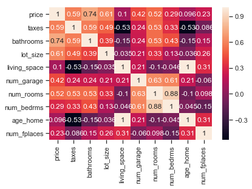

```python
corr = df[df.columns].corr()
print(corr)
sns.heatmap(corr, annot = True)
```

Scatter plots are a good way to begin and should reveal relationships between the target variable, price and each explanatory variable.

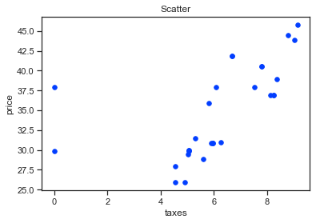

```python
def scat(dataframe,var1,var2):
    plt.scatter(dataframe[var1],dataframe[var2], s = 30)
    plt.title('Scatter')
    plt.xlabel(var1)
    plt.ylabel(var2)

scat(df, 'taxes', 'price')
```

Zero values definitely causing problems. Seaborn with color plots for a third variable will show if there is value in a two variable model. num_garage looks promising but data is a bit sparse for this variable.

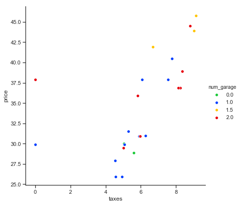

```python
import seaborn as sns
sns.set(style="ticks", palette="bright")
sns.pairplot(x_vars=["taxes"], y_vars=["price"], data=df, hue="num_garage",
             palette=["g", "b", "y", "r"],height = 6)
```

# Section 2 Base Model and RMSE

Run a base model and calculate the root mean square error for the model. Kaggle is set up to score your models using RMSE and my score code also uses RMSE. However, I have penalty's for out of range predictions and missing predictions so make sure none of these will apply to your model predictions.

Using the statsmodels API for this linear model and taxes for the single prediction variable. Taxes will be used for the single prediction variable for each of the sections where the change will be improvement in the data due to the EDA. Result will be model RMSE improvement due to the EDA rather than changes to the input variable.

```python
base_model = smf.ols(formula='price ~ taxes', data=df).fit()
base_model.summary()
predictions = base_model.fittedvalues
predictions.head()
```

```
0    33.003663
1    33.163371
2    32.422201
3    32.443909
4    33.223843
dtype: float64
```

Join the model predictions data with actual price to calculate BASE_RMSE.

```python
d = {'p_price': predictions}
d1=pd.DataFrame(data=d)
join = pd.concat([df,d1],axis = 1, join_axes=[df.index])
join['sq_error'] = (join['price'] - join['p_price'])**2
mean_sq_error =  np.sqrt(join.sq_error).mean()
BASE_RMSE = np.around([mean_sq_error], decimals=2)
BASE_RMSE
```

```
array([3.97])
```

Look at a scatter plot of price vs p_price to see if this model looks reasonable.

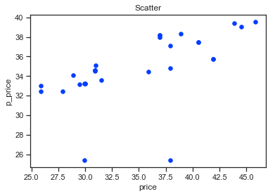

```python
scat(join, 'price', 'p_price')
```

Not good. Need to fix those outliers and get rid of any duplicate records.

# Section 3 RMSE (after removing duplicate records)

Note, there are 5 duplicate records dropped from the dataframe.

```python
df1 = df.drop_duplicates(keep='first')
print('Number of Records:', len(df1))
```

```
Number of Records: 24
```

```python
Model the data with the nodups dataset df1:
```

```python
nodups_model = smf.ols(formula='price ~ taxes', data=df1).fit()
nodups_model.summary()
nodups_preds = nodups_model.fittedvalues
nodups_preds.head()
```

```
0    33.046073
1    33.197726
2    32.493937
3    32.514551
4    33.255148
dtype: float64
```

Calculate the NODUPS_RMSE:

```python
d = {'p_price': nodups_preds}
d2=pd.DataFrame(data=d)
join = pd.concat([df,d2],axis = 1, join_axes=[df.index])
join['sq_error'] = (join['price'] - join['p_price'])**2
mean_sq_error =  np.sqrt(join.sq_error).mean()
NODUPS_RMSE = np.around([mean_sq_error], decimals=2)
NODUPS_RMSE
```

```
array([4.1])
```

OK No help for RMSE. The RMSE is not reduced. Need to deal with outliers next.

# Section 4 RMSE Score (after EDA fixing outliers and missing data)

Fix the outliers and missing 9999 values then summarize the data to see if looks OK.

```python
df2 = df1.copy()
df2=df2.replace({'living_space': {9999: 0}})
df2=df2.replace({'age_home': {9999: 0}})
m = np.median(df2.taxes[df2.taxes>0])
df2=df2.replace({'taxes': {0: m}})
n = np.median(df2.lot_size[df2.lot_size>0])
df2=df2.replace({'lot_size': {0: n}})
p = np.median(df2.living_space[df2.living_space>0])
df2=df2.replace({'living_space': {0: p}})
q = np.median(df2.age_home[df2.age_home>0])
df2=df2.replace({'age_home': {0: q}})
```

```python
dfdesc = df2.describe(include = "all")
dfdesc
```

|  | price | taxes | bathrooms | lot_size | living_space | num_garage | num_rooms | num_bedrms | age_home | num_fplaces |
| --- | --- | --- | --- | --- | --- | --- | --- | --- | --- | --- |
| count | 24.000000 | 24.000000 | 24.000000 | 24.000000 | 24.000000 | 24.000000 | 24.000000 | 24.000000 | 24.000000 | 24.000000 |
| mean | 34.629167 | 6.494958 | 1.166667 | 6.090792 | 1.376542 | 1.312500 | 6.500000 | 3.166667 | 36.041667 | 0.250000 |
| std | 6.012702 | 1.491552 | 0.240772 | 1.936369 | 0.262751 | 0.604557 | 0.884652 | 0.564660 | 13.889249 | 0.442326 |
| min | 25.900000 | 4.543000 | 1.000000 | 2.275000 | 0.975000 | 0.000000 | 5.000000 | 2.000000 | 3.000000 | 0.000000 |
| 25% | 29.900000 | 5.240000 | 1.000000 | 4.997000 | 1.161500 | 1.000000 | 6.000000 | 3.000000 | 30.000000 | 0.000000 |
| 50% | 33.700000 | 6.021000 | 1.000000 | 5.850000 | 1.432000 | 1.000000 | 6.000000 | 3.000000 | 32.000000 | 0.000000 |
| 75% | 38.150000 | 7.873000 | 1.500000 | 7.158000 | 1.516000 | 2.000000 | 7.000000 | 3.250000 | 47.000000 | 0.250000 |
| max | 45.800000 | 9.142000 | 1.500000 | 9.890000 | 1.831000 | 2.000000 | 8.000000 | 4.000000 | 62.000000 | 1.000000 |

Much better. OK for homes not to have a garage or a fireplace.

Model with df2 with outlier and missing data fixes in place.

```python
taxes_model = smf.ols(formula='price ~ taxes', data=df2).fit()
taxes_model.summary()
taxes_preds = taxes_model.fittedvalues
taxes_preds.head()
```

```
0    29.044122
1    29.408913
2    27.716001
3    27.765584
4    29.547037
dtype: float64
```

Calculate TAXES_RMSE for the nodups, no outliers and no missing values data df2.

```python
d = {'p_price': taxes_preds}
d2=pd.DataFrame(data=d)
join = pd.concat([df,d2],axis = 1, join_axes=[df.index])
join['sq_error'] = (join['price'] - join['p_price'])**2
mean_sq_error =  np.sqrt(join.sq_error).mean()
TAXES_RMSE = np.around([mean_sq_error], decimals=2)
TAXES_RMSE
```

```
array([2.26])
```

Big improvement down from 3.97 for the BASE_MODEL.

In addition, look at all three models with some other summary measures. This makes for a nice look in a report.

```python
base_df = pd.DataFrame({'R2_Adj':base_model.rsquared_adj,
                        'Prob (F-Stat)':base_model.f_pvalue,
                        'AIC':base_model.aic,
                        'MSE_Residual': base_model.resid,
                        'F-Value': base_model.fvalue,
                        'BIC':base_model.bic,
                        'Residual_Skew': base_model.resid.skew(),
                        'Residual_Kurt' : base_model.resid.kurt()}, index = [1])
```

```python
nodups_df = pd.DataFrame({'R2_Adj':nodups_model.rsquared_adj,
                        'Prob (F-Stat)':nodups_model.f_pvalue,
                        'AIC':nodups_model.aic,
                        'MSE_Residual': nodups_model.resid,
                        'F-Value': nodups_model.fvalue,
                        'BIC':nodups_model.bic,
                        'Residual_Skew': nodups_model.resid.skew(),
                        'Residual_Kurt' : nodups_model.resid.kurt()}, index = [1])
```

```python
taxes_df = pd.DataFrame({'R2_Adj':taxes_model.rsquared_adj,
                        'Prob (F-Stat)':taxes_model.f_pvalue,
                        'AIC':taxes_model.aic,
                        'MSE_Residual': taxes_model.resid,
                        'F-Value': taxes_model.fvalue,
                        'BIC':taxes_model.bic,
                        'Residual_Skew': taxes_model.resid.skew(),
                        'Residual_Kurt' : taxes_model.resid.kurt()}, index = [1])
```

```python
ModelSummary = pd.concat([base_df,
                           nodups_df,
                           taxes_df
])
```

```python
ModelSummary
```

|  | R2_Adj | Prob (F-Stat) | AIC | MSE_Residual | F-Value | BIC | Residual_Skew | Residual_Kurt |
| --- | --- | --- | --- | --- | --- | --- | --- | --- |
| 1 | 0.322850 | 7.731283e-04 | 175.355194 | -3.663371 | 14.349784 | 178.089785 | 0.673968 | 0.008179 |
| 1 | 0.306277 | 2.967623e-03 | 147.350346 | -3.697726 | 11.154466 | 149.706454 | 0.623560 | -0.140416 |
| 1 | 0.761512 | 1.646602e-08 | 121.724268 | 0.091087 | 74.440929 | 124.080375 | 0.674233 | -0.200192 |

Taxes model with removal of duplicate records and fixes for outliers and missing data show major improvement for the simple single variable model. Still more you can do by including other variables. Since this is an EDA example, stop here and leave the remainder model improvement to you.

One more look at a pairplot for price vs p_price with the single variable model:

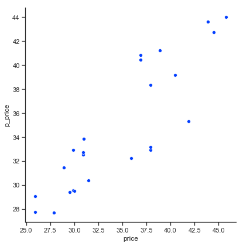

```python
sns.set(style="ticks", palette="bright")
sns.pairplot(x_vars=["price"], y_vars=["p_price"], data=join, height = 6)
```

Much improvement. More work to do. You can find a better model. Take a look at the scatter plots below to see where you might go next.

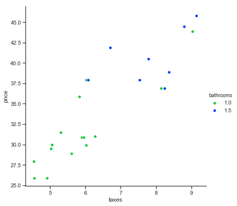

```python
import seaborn as sns
sns.set(style="ticks", palette="bright")
sns.pairplot(x_vars=["taxes"], y_vars=["price"], data=df2, hue="bathrooms",
             palette=["g", "b"],height = 6)
```

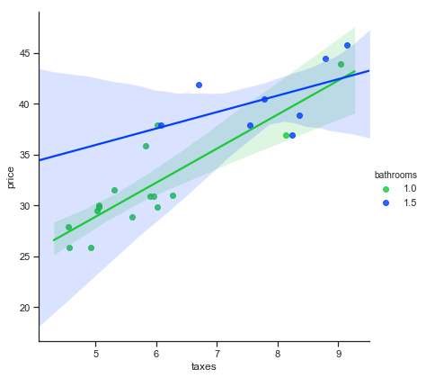

```python
sns.set(style="ticks", palette="bright")
sns.pairplot(x_vars=["taxes"], y_vars=["price"], data=df2, hue="bathrooms", kind="reg",
             palette=["g", "b"],height = 6)
```

Bathrooms may be a good addition to the model. Maybe something else too. You decide.